# Explore and Summarize data project with R

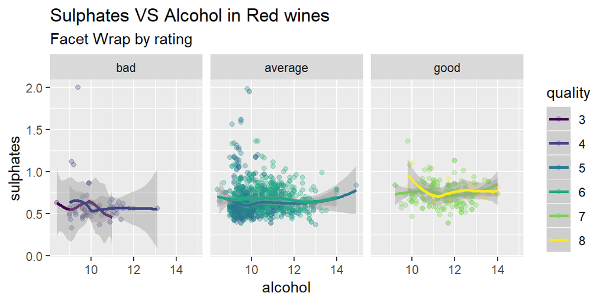

- Although high quality red wines tend to have higher sulphates conc., but the effect of sulphates here is not quiet clear to determine its effect on quality specially for the higher variability in the avearge group.

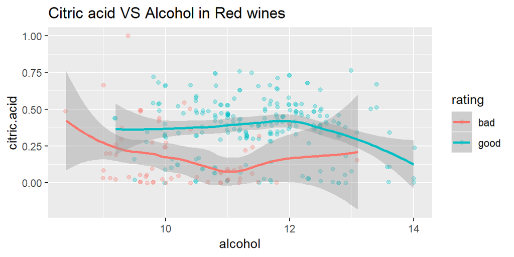

- Although citric acid is resposible for freshness at low concentration, but as per the above plot I noticed that most of higher quality red wines have a higher concentration of citric acid and the majority at 0 for bad quality.

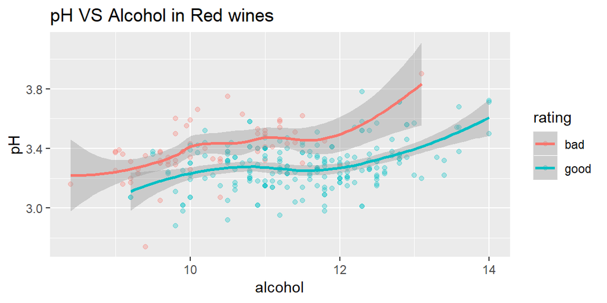

- Although the correlation between quality and pH was *-0.1* , but here high quality wines has tendency for lower pH specially less than *3.2* which sounds logic as higher quality alcohol tend to have more citric acid and fixed acidity which for sure leads to lower pH values.

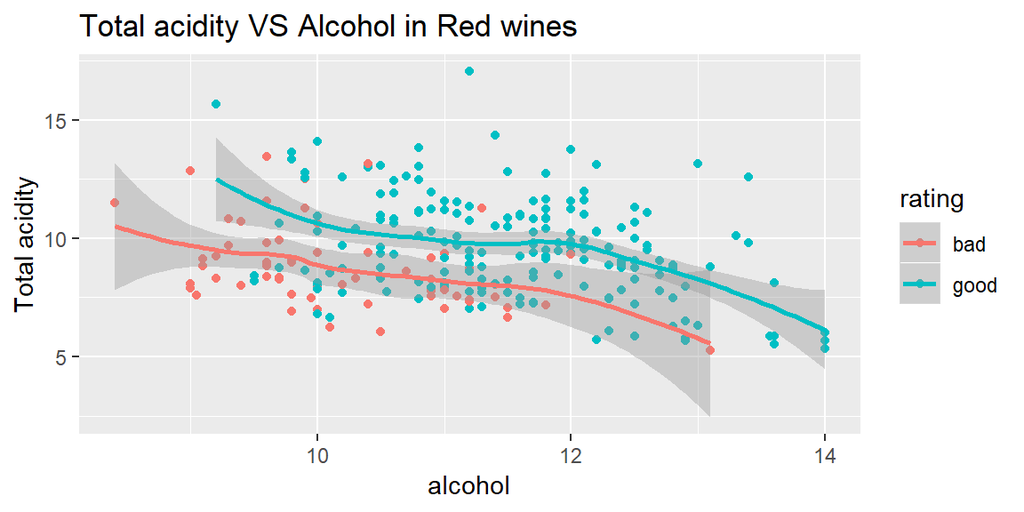

- Intersting point here as although higher quality red wines tend to have less volatile acidity but the overall comined acidity in them is higher which reflects the pH values to be smaller in compasion to bad quality ones.

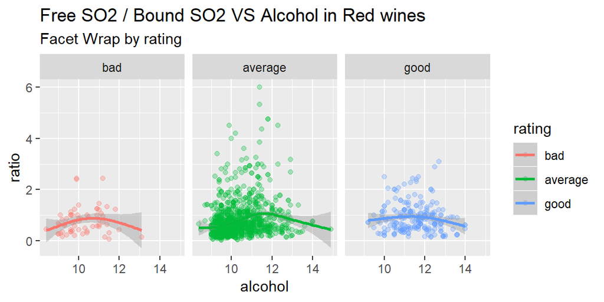

- As a try to calculate the ratio of free SO2 to bound SO2, it seems that all the quality levels behave in the same trend with majority having ratio less than 1 except for the variance in the average group.

# Multivariate Analysis

#### Talk about some of the relationships you observed in this part of the investigation. Were there features that strengthened each other in terms of looking at your feature(s) of interest?

High quality red wines have the largest median & mean for alcohol concentration.

In comparing to alcohol, I found that high quality alcohols tends to have higher fixed acidity and citric acid, but lower volatile acidity and pH.

No effect for sulphates neither nor ration of Free SO2: Bound SO2.

#### Were there any interesting or surprising interactions between features?

By measuring Fixed acidity to volatile acidity ration, I noticed that the higher qulaity red wines tend to have higher ratio above 20.

Despite the positive correlation between quality and sulphates but I conclude that sulphates acts in different manner in compaing to alcohol across all rating levels

Although the correlation between quality and pH was too weak and negative , but high quality wines has tendency for lower pH specially less than 3.2.

Citric acid is higher in high quality red wines than in bad quality.

# Final Plots and Summary

### Plot One

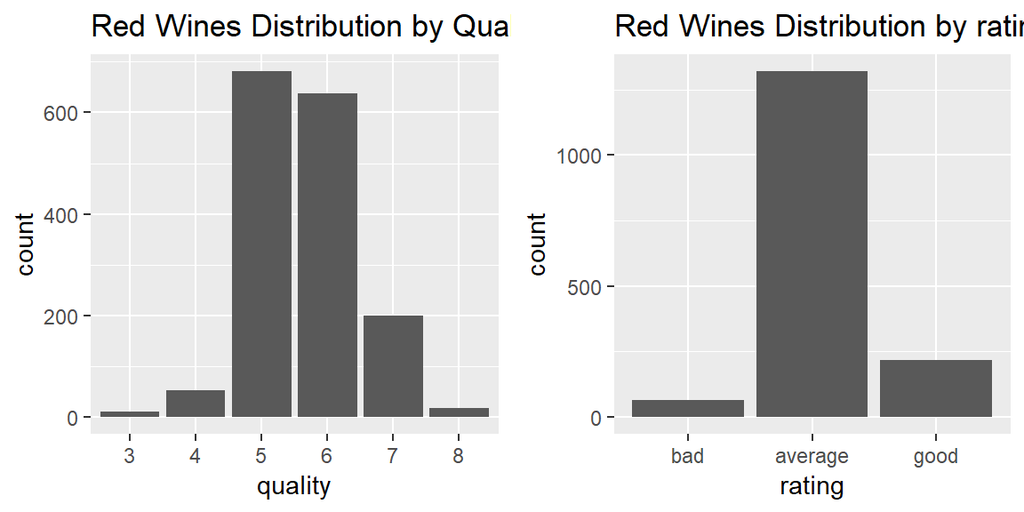

### Description One

The histogram shows clearly that most of the red wines quality on sclaes 5 & 6 and so they have the average rating.

### Plot Two

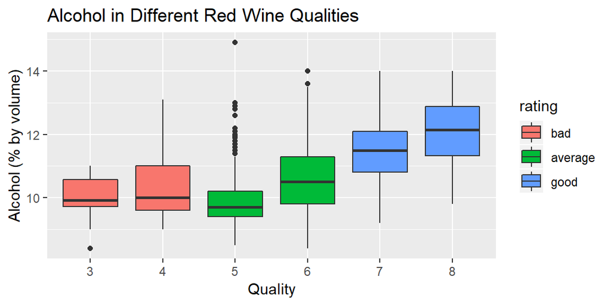

### Description Two

The boxplots here show good quality red wines has the largest median Alcohol compared to the other qualities, it’s obvious..

### Plot Three

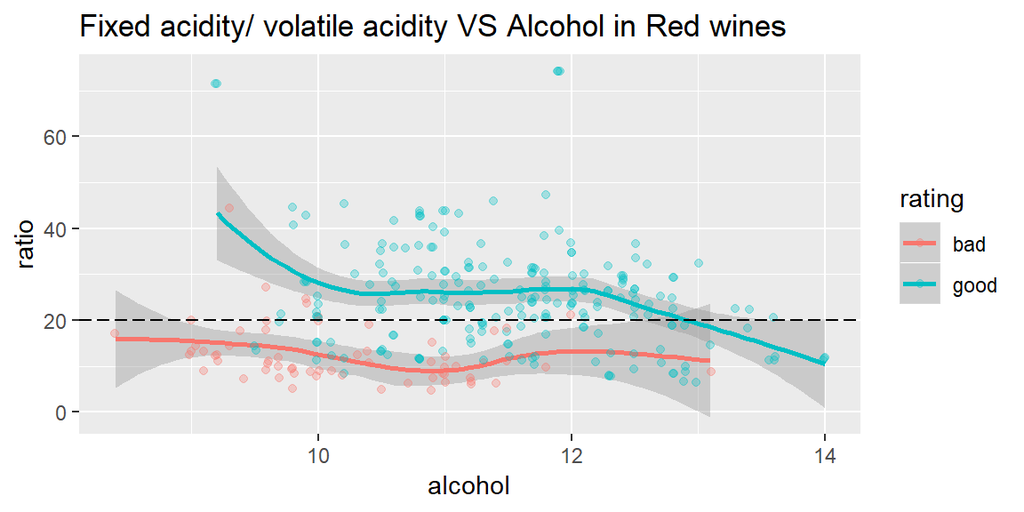

### Description Three

The higher qulaity red wines tend to have higher fixed acidity to volatile acidity ratio above 20, also the majority of average & bad red wines at different concentration of alcohol tends to have fixed:volatile ratio at below that line.

# Reflection

There was a clear trend between the alcohol concentration or volatile acidity of a red wine and its quality. I was surprised that citric acid did not have a strong positive correlation with quality. I struggled understanding the variance in quality as the level of Free S02 & Total SO2 get increased, but this became more clear when I realized that most of the data contained average rating of quality rank 5 &6.

Some limitations of this data include:

- The source of the data. Given that the red wines date to 2009.
- The imbalance nature of the data most of the quality related to the average group.
- It’s related to only one brand , quality could be differed in presence of other brand
- I have not expeeinced before with wine, so I guess in this topic domain experience is usefull, and this could suggest the idea of using addictive wine user for the test.
- As per my google search people generally have individual preference for wines, even that each occassion has its own wine atmosphere and kind, with meal or without, party or gift.
- Some other variables could be added like tannins content

# Resources

- Pimp my RMD
- The R markdown website
- Correlation plots
- Github corner

A work by [Mohamed Hindam](https://github.com/hindamosh/)

*hindamosh@gmail.com*